# LDA tutorial

### Work with both height and weight

Now, let us include both the features in our LDA model.

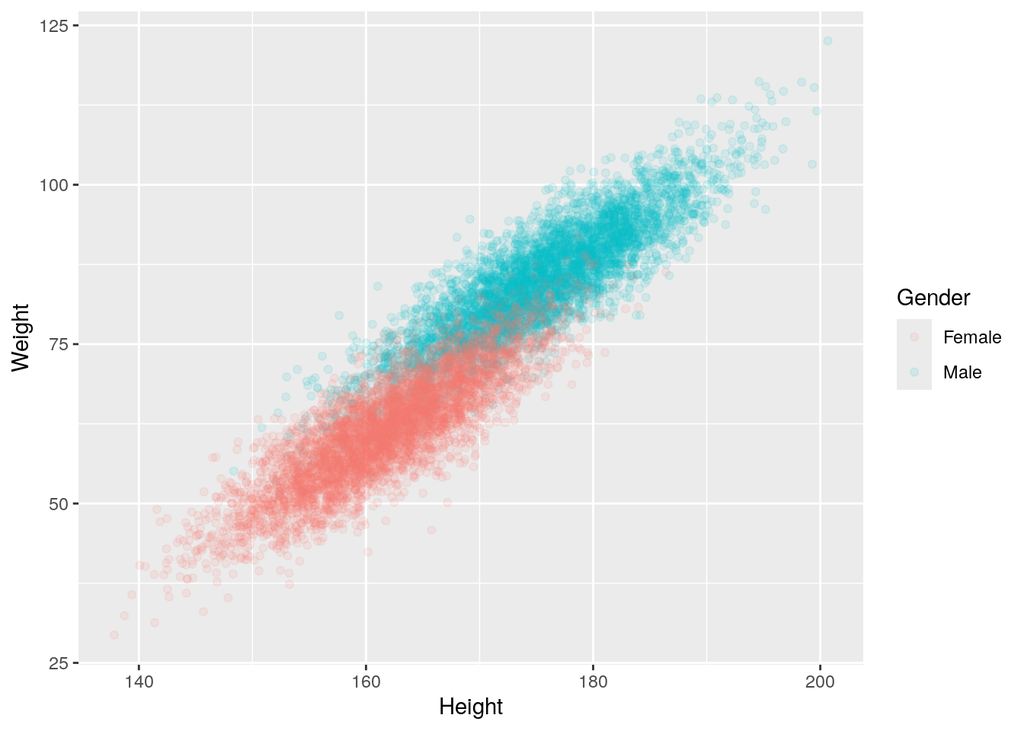

```r
# First, observe, how the multivariate normal distributions of Height + Weight looks
life_data %>%
  ggplot(aes(x=Height, y=Weight, col=Gender)) +
  geom_point(alpha=0.1)
```

```r
# run LDA function
lda_hw <- lda(Gender ~ ., life_data)
lda_hw
```

```
## Call:
## lda(Gender ~ ., data = life_data)
##
## Prior probabilities of groups:
## Female   Male
##    0.5    0.5
##
## Group means:
##          Height   Weight
## Female 161.8203 61.68048
## Male   175.3269 84.90736
##
## Coefficients of linear discriminants:
##                LD1
## Height -0.06766107
## Weight  0.15646959
```

```r
gender_pred <- predict(lda_hw, life_data)$class

# Accuracy, by 8% better than with Height only
my_accuracy(gender_pred, life_data$Gender)
```

```
##
##  Accuracy: 0.9193
```

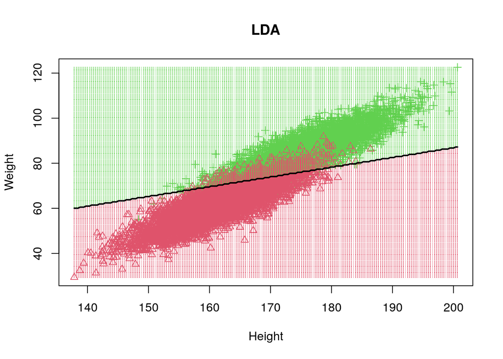

```r
decisionplot(lda_hw, life_data, class = "Gender", main = "LDA", resolution=200)
```

```r
# Question: Again, why is the decision boundary linear?
# Short answer: Using the formula for the normal distribution density and setting P(man|X)=P(woman|X) we can
# derive a term for the boundary, which will be linear in X.
# For details refer to "Introduction to statistical learning in R", page 142
```

With weight, the accuracy improves to nearly 92%. The decision boundary is linear. The coefficients of linear discriminants returned by the lda() function represent the weights used to transform the predictor variables into a new space where the classes are best separated. Additionally, they represent the normal vector to the decision boundary, i.e., the vector that is perpendicular to this boundary.

### LDA with two predictors perfomed with the Bayes formula

With two features, the Bayes formula extends to: $Pr(Male|Height,Weight) = \frac{Pr(Height,Weight|Male)} {Pr(Height,Weight|Male) + Pr(Height,Weight|Female)}$

```r
# estimate parameters of distributions, substitute them into the Bayes formula
library(mvtnorm)
mu_f <- colMeans(life_data[life_data$Gender=="Female",c(2,3)])
mu_m <- colMeans(life_data[life_data$Gender=="Male",c(2,3)])
cov_f <- cov(life_data[life_data$Gender=="Female",c(2,3)])
cov_m <- cov(life_data[life_data$Gender=="Male",c(2,3)])
cov_avg <- (cov_f + cov_m)/2

# Again, compute the posterior for the samples (simplified by the fact that P(Male)=P(Female))
postM <- dmvnorm(life_data[c(2,3)], mu_m, cov_avg) /
  (dmvnorm(life_data[c(2,3)], mu_m, cov_avg) + dmvnorm(life_data[c(2,3)], mu_f, cov_avg))
head(postM)
```

```
##          1          2          3          4          5          6
## 0.99999416 0.27675255 0.99815610 0.99985189 0.99912096 0.09998952
```

```r
gender_pred <- postM > 0.5

my_accuracy(gender_pred, life_data$Gender)
```

```
##
##  Accuracy: 0.9193
```

```r
# The train accuracy of Logistic regression was 0.9194
```

## Quadratic discriminant analysis (QDA)

Although it looks that the LDA assumptions are met, we will run QDA and thus allow each class to have its own covariance matrix. It means the spread and correlation of the predictors can vary between classes. We will deal with more model parameters and make our model more flexible.

```r
qda_res <- qda(Gender ~ .,life_data)
qda_res
```

```
## Call:
## qda(Gender ~ ., data = life_data)
##
## Prior probabilities of groups:
## Female   Male
##    0.5    0.5
##
## Group means:
##          Height   Weight
## Female 161.8203 61.68048
## Male   175.3269 84.90736
```

```r
gender_pred <- predict(qda_res, life_data)$class

# Evaluate accuracy
# almost the same train accuracy as LDA, more freedom does not help here
my_accuracy(gender_pred, life_data$Gender)
```

```
##
##  Accuracy: 0.9192
```

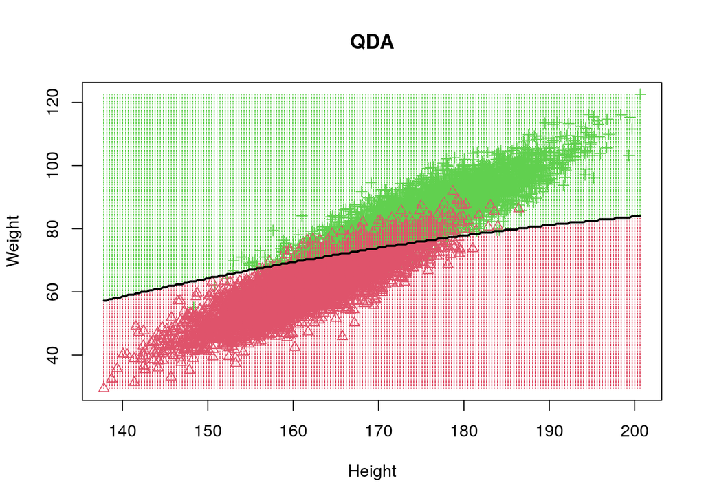

```r
decisionplot(qda_res, life_data, class = "Gender", main = "QDA", resolution=200) # decision boundary close to linear
```

```r
qda_res$scaling # both the genders scale nearly equally (scaling transforms the observations so that within-group covariance matrices are spherical)
```

```
## , , Female
##
##                1          2
## Height 0.1460161 -0.2352167
## Weight 0.0000000  0.2195462
##
## , , Male
##
##                1          2
## Height -0.137496 -0.2348510
## Weight  0.000000  0.2203915
```

```r
var(as.matrix(subset(life_data, Gender=="Male",2:3)) %*% qda_res$scaling[,,"Male"]) # after scaling, the group variances equal 1 and covariances 0
```

```
##               1             2
## 1  1.000000e+00 -1.795308e-15
## 2 -1.795308e-15  1.000000e+00
```

QDA reaches approximately the same train accuracy as LDA, it seems that additional complexity does not help much. The decision boundary in QDA can take the form of parabolas, ellipses, or hyperbolas in 2D space, or their higher-dimensional equivalents. In our case it is close to linear as the class covariance matrices do not differ much.

## Logistic regression

Finally, we will perform both the previously solved classification tasks with logistic regression. We will start with the simple height model.

```r
# run Logistic regression - start with a simple Height model
lr <- glm(Gender ~ Height, life_data, family=binomial)
# Look the model - does a coefficient for Height have any (meaningful) interpretation?
# Maybe revise what quantity the Y = B0+B1x1+... represents in the logistic regression
lr
```

```
##
## Call:  glm(formula = Gender ~ Height, family = binomial, data = life_data)
##
## Coefficients:
## (Intercept)       Height
##    -45.3001       0.2689
##
## Degrees of Freedom: 9999 Total (i.e. Null);  9998 Residual
## Null Deviance:       13860
## Residual Deviance: 7542  AIC: 7546
```

```r
# Obtain the probability of being a Man for train data
lr_prob <- predict(lr, life_data, type="response")
gender_pred <- lr_prob > 0.5

# Compare the 2 calls below. Can you guess how do they differ and how to get from one to the other?
# HINT: Recall, how to get from Y = B0+B1x1+... to the probability
predict(lr, life_data, type="response") %>% head
```

```
##         1         2         3         4         5         6
## 0.9941160 0.8416663 0.9950788 0.9755074 0.9184738 0.6517203
```

```r
predict(lr, life_data)                  %>% head
```

```
##         1         2         3         4         5         6
## 5.1296161 1.6706788 5.3092777 3.6845852 2.4217888 0.6266095
```

```r
# Evaluate accuracy of Logistic regression
my_accuracy(gender_pred, life_data$Gender, print_confmat = TRUE)
```

```
##
## Confusion matrix:
##        reference
## preds   Female Male
##   FALSE   4171  845
##   TRUE     829 4155
##
##  Accuracy: 0.8326
```

```r
# Prepare data to plot the sigmoid
sigmoid_data <- life_data %>%
  mutate(lr_prob = lr_prob,
         gender_num = as.numeric(Gender) - 1)

# Using the sigmoid data, estimate the decision boundary of the logistic regression
# You will see a better way to analytically find the decision boundary
lr_decisionBoundary <- sigmoid_data %>% filter(lr_prob > 0.5) %>% pull(Height) %>% min() %>% round(digits=3)
# compared to lda_decisionBoundary, a tiny difference exists
sprintf("LR decision boundary: %s", lr_decisionBoundary)
```

```
## [1] "LR decision boundary: 168.498"
```

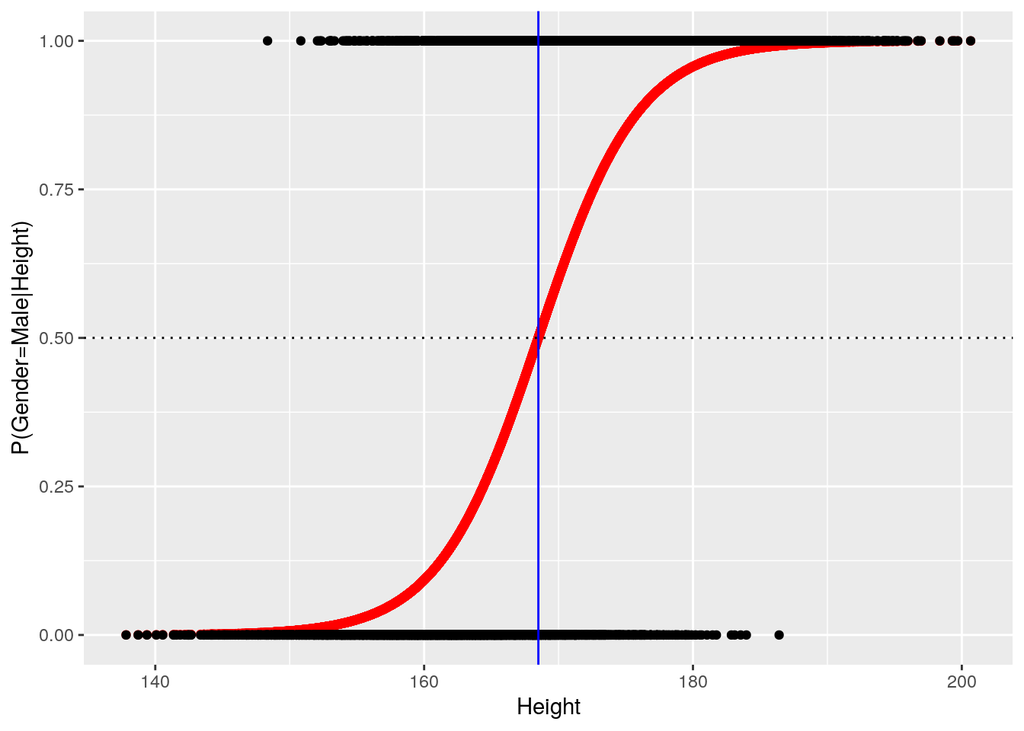

```r
# Plot the sigmoid
sigmoid_data %>%
  ggplot(aes(x=Height, y=lr_prob)) +
  geom_point(col="red") +
  geom_point(aes(x=Height, y=gender_num)) +
  # Logistic regression decision boundary
  geom_vline(xintercept = lr_decisionBoundary, col="blue") +
  geom_hline(yintercept = 0.5, linetype="dotted") +
  ylab("P(Gender=Male|Height)")
```

The logistic regression decision boundary as well as train accuracy nearly perfectly match the outcomes obtained by LDA. Both the methods have sufficient amount of data to learn, the problem is simple, the conceptual differences between methods do not matter in this task.

### Fit LR with both Height and Weight

```r
lr_hw <- glm(Gender ~ ., life_data, family=binomial)
lr_hw
```

```
##
## Call:  glm(formula = Gender ~ ., family = binomial, data = life_data)
##
## Coefficients:
## (Intercept)       Height       Weight
##      0.6925      -0.1939       0.4369
##
## Degrees of Freedom: 9999 Total (i.e. Null);  9997 Residual
## Null Deviance:       13860
## Residual Deviance: 4183  AIC: 4189
```

```r
# Predict the gender and assess the accuracy
gender_pred <- predict(lr_hw, life_data, type = "response") > 0.5
my_accuracy(gender_pred, life_data$Gender)
```

```
##
##  Accuracy: 0.9194
```

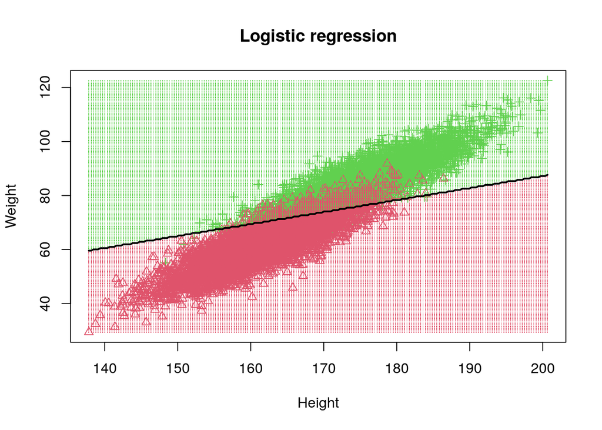

```r
# Plotting decision boundary
class(lr_hw) <- c("lr", class(lr_hw)) # a bit of adjusting for plotting the decision boundary
# the decision boundary is linear!
predict.lr <- function(object, newdata, ...)
  predict.glm(object, newdata, type = "response") > .5
decisionplot(lr_hw, life_data, class = "Gender", main = "Logistic regression", resolution=200)
```

```r
# Question: Why is the logistic regression decision boundary linear? Can you derive the equation?
# HINT: Refer again to the equation of LR. What probability do the points lying on the decision boundary have?
```

Again, the decision boundary and train accuracy nearly perfectly match the outcomes obtained by LDA. Let us compare the decision boundary slope from the coefficients. In LDA, the normalized normal vector is -0.3969039, 0.9178602, in LR the same vector equals -0.4057524, 0.913983. The vectors can be reached from the coefficents obtained in both the methods.

## Independent work

1. Which method is expected to perform best on the test data in this task (LDA, QDA or LR)? Answer without running any tests, using only the assumptions underlying each method.
2. Experimentally verify your answer. Note that you may need to work with different (and sometimes very small) training sets to observe any differences, as you have already seen that for 10,000 samples the differences can be negligible.
3. Compare the methods in terms of their robustness to outliers. Begin with a brief theoretical justification, then verify your conclusions experimentally.